# Random Forest

D. Howell

11/02/2020

## Intro

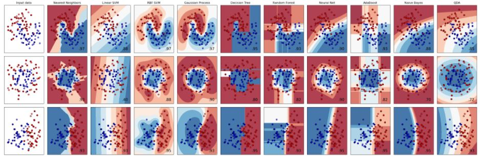

- Model Notes:
- random forest is a aggregation of multiple decision tree models
- decision boundary is in the form of several rectandular sections
- robust to different types of analysis, but prone to overfitting - must be "pruned"
- Model Uses
- Classification, some regression
- supervised machine learning
- Model Input
- Countinuous and discrete
- Model Output
- Discrete, but can also perform regression
- Model Fitting Algorithm
- Decision tree
  - separate on variables that provide the most distinction between classes
  - continue separating until max depth has been reached
- Random Forest
  - run several decision trees at set depth, selecting variables to split on by choosing the best one among a preset number of randomly chosen variables from the test set.
  - aggregate the models into one tree

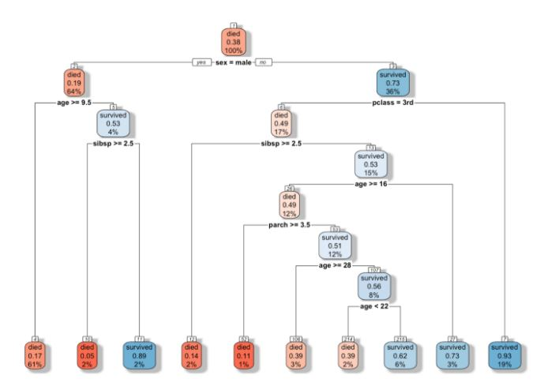

### RF Decision Boundary

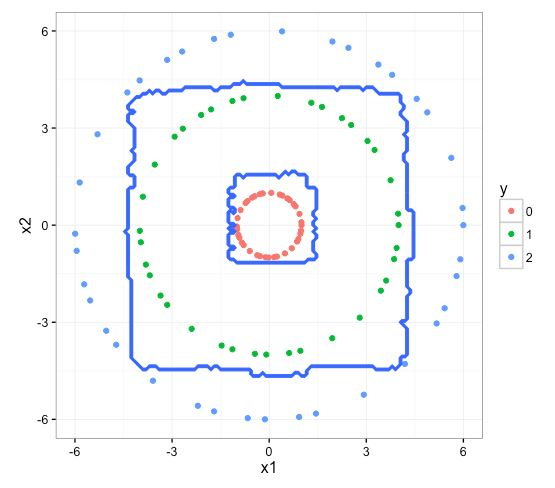

### SVM Decision Boundary

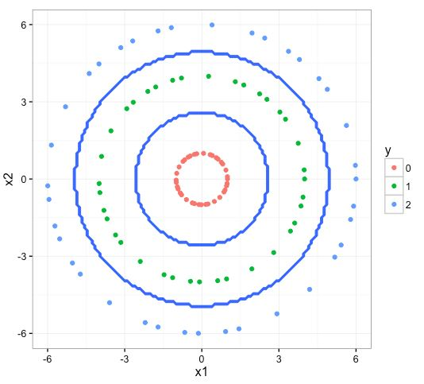

### Neural Net Decision Boundary

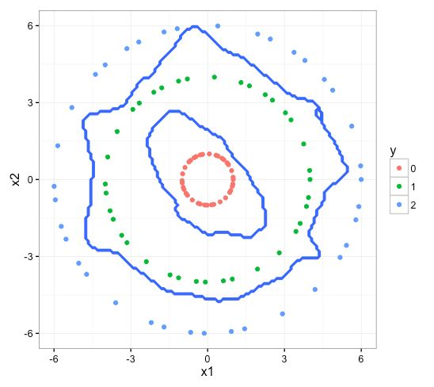

### Example

- age: age in years
- sex: sex (1 = male; 0 =female)
- cp: chest pain type (1 = typical angina; 2 = atypical angina; 3 = non-anginal pain; 4 = asymptomatic)
- trestbps: resting blood pressure (in mm Hg on admission to the hopsital)
- choi: serum cholestoral in mg/dl
- fbs: fasting blood sugar > 120 mg/dl (1 = true; = 0 false)
- restecg: resting electrocardiographic results (1 = normal; 2 = having ST-T wave abnormality; 2 = showing probable or definite left ventricular * hypertrophy)
- thalach: maximum heart rate achieved
- exang: exercise induced angina (1 = yes; 0 = no)
- oldpeak: ST depression induced by exercise relative to rest
- slope: the slope of the peak exercise ST segment (1 = upsloping; 2 = flat; 3 = downsloping)
- ca: number of major vessels (0–3) colored by flourosopy
- thai: (3 = normal; 6 = fixed defect; 7 = reversable defect)
- num: diagnosis of heart disease. It is an integer valued from 0 (no presence) to 4.

```r
library(randomForest)
require(caTools)

data <- read.csv(
  "/Users/drewhowell/Desktop/CSC-201/2020_Fall/20201102_Random_Forest/processed.cleveland.data",
  header=FALSE
)

dim(data)
```

```
## [1] 303  14
```

```r
names(data) <- c("age", "sex", "cp", "trestbps", "choi", "fbs", "restecg", "thalach", "exang", "oldpeak", "slope", "ca", "thai", "num")

data$num[data$num > 1] <- 1

sapply(data, class)
```

```
##         age         sex          cp    trestbps        choi         fbs
##   "numeric"   "numeric"   "numeric"   "numeric"   "numeric"   "numeric"
##     restecg     thalach       exang     oldpeak       slope          ca
##   "numeric"   "numeric"   "numeric"   "numeric"   "numeric" "character"
##        thai         num
## "character"   "numeric"
```

```r
data <- transform(
  data,
  age=as.integer(age),
  sex=as.factor(sex),
  cp=as.factor(cp),
  trestbps=as.integer(trestbps),
  choi=as.integer(choi),
  fbs=as.factor(fbs),
  restecg=as.factor(restecg),
  thalach=as.integer(thalach),
  exang=as.factor(exang),
  oldpeak=as.numeric(oldpeak),
  slope=as.factor(slope),
  ca=as.factor(ca),
  thai=as.factor(thai),
  num=as.factor(num)
)
sapply(data, class)
```

```
##       age       sex        cp  trestbps      choi       fbs   restecg   thalach
## "integer"  "factor"  "factor" "integer" "integer"  "factor"  "factor" "integer"
##     exang   oldpeak     slope        ca      thai       num
##  "factor" "numeric"  "factor"  "factor"  "factor"  "factor"
```

```r
data[ data == "?"] <- NA
colSums(is.na(data))
```

```
##      age      sex       cp trestbps     choi      fbs  restecg  thalach
##        0        0        0        0        0        0        0        0
##    exang  oldpeak    slope       ca     thai      num
##        0        0        0        4        2        0
```

```r
data$thai[which(is.na(data$thai))] <- as.factor("3.0")
data <- data[!(data$ca %in% c(NA)),]
colSums(is.na(data))
```

```
##      age      sex       cp trestbps     choi      fbs  restecg  thalach
##        0        0        0        0        0        0        0        0
##    exang  oldpeak    slope       ca     thai      num
##        0        0        0        0        0        0
```

```r
summary(data)
```

```
##       age        sex     cp         trestbps          choi       fbs
##  Min.   :29.00   0: 97   1: 23   Min.   : 94.0   Min.   :126.0   0:255
##  1st Qu.:48.00   1:202   2: 49   1st Qu.:120.0   1st Qu.:211.0   1: 44
##  Median :56.00           3: 84   Median :130.0   Median :242.0
##  Mean   :54.53           4:143   Mean   :131.7   Mean   :247.1
##  3rd Qu.:61.00                   3rd Qu.:140.0   3rd Qu.:275.5
##  Max.   :77.00                   Max.   :200.0   Max.   :564.0
##  restecg    thalach      exang      oldpeak      slope     ca       thai
##  0:148   Min.   : 71.0   0:201   Min.   :0.000   1:140   ?  :  0   ?  :  0
##  1:  4   1st Qu.:133.0   1: 98   1st Qu.:0.000   2:138   0.0:176   3.0:166
##  2:147   Median :153.0           Median :0.800   3: 21   1.0: 65   6.0: 18
##          Mean   :149.5           Mean   :1.052           2.0: 38   7.0:115
##          3rd Qu.:165.5           3rd Qu.:1.600           3.0: 20
##          Max.   :202.0           Max.   :6.200
##  num
##  0:161
##  1:138
##
##
##
##
```

```r
data$ca <- factor(data$ca)
data$thai <- factor(data$thai)
summary(data)
```

```
##       age        sex     cp         trestbps          choi       fbs
##  Min.   :29.00   0: 97   1: 23   Min.   : 94.0   Min.   :126.0   0:255
##  1st Qu.:48.00   1:202   2: 49   1st Qu.:120.0   1st Qu.:211.0   1: 44
##  Median :56.00           3: 84   Median :130.0   Median :242.0
##  Mean   :54.53           4:143   Mean   :131.7   Mean   :247.1
##  3rd Qu.:61.00                   3rd Qu.:140.0   3rd Qu.:275.5
##  Max.   :77.00                   Max.   :200.0   Max.   :564.0
##  restecg    thalach      exang      oldpeak      slope     ca       thai
##  0:148   Min.   : 71.0   0:201   Min.   :0.000   1:140   0.0:176   3.0:166
##  1:  4   1st Qu.:133.0   1: 98   1st Qu.:0.000   2:138   1.0: 65   6.0: 18
##  2:147   Median :153.0           Median :0.800   3: 21   2.0: 38   7.0:115
##          Mean   :149.5           Mean   :1.052           3.0: 20
##          3rd Qu.:165.5           3rd Qu.:1.600
##          Max.   :202.0           Max.   :6.200
##  num
##  0:161
##  1:138
##
##
##
##
```

```r
sample = sample.split(data$num, SplitRatio = .75)
train = subset(data, sample == TRUE)
test  = subset(data, sample == FALSE)
dim(train)
```

```
## [1] 225  14
```

```r
dim(test)
```

```
## [1] 74 14
```

```r
rf <- randomForest(
  num ~ .,
  data=train
  ,mtry = 6
  ,ntree = 500
)
rf
```

[output not shown]

```r
pred = predict(rf, newdata=test[-14])

cm = table(test[,14], pred)

library(caret)
gbmImp <- varImpPlot(rf, type=2)
```

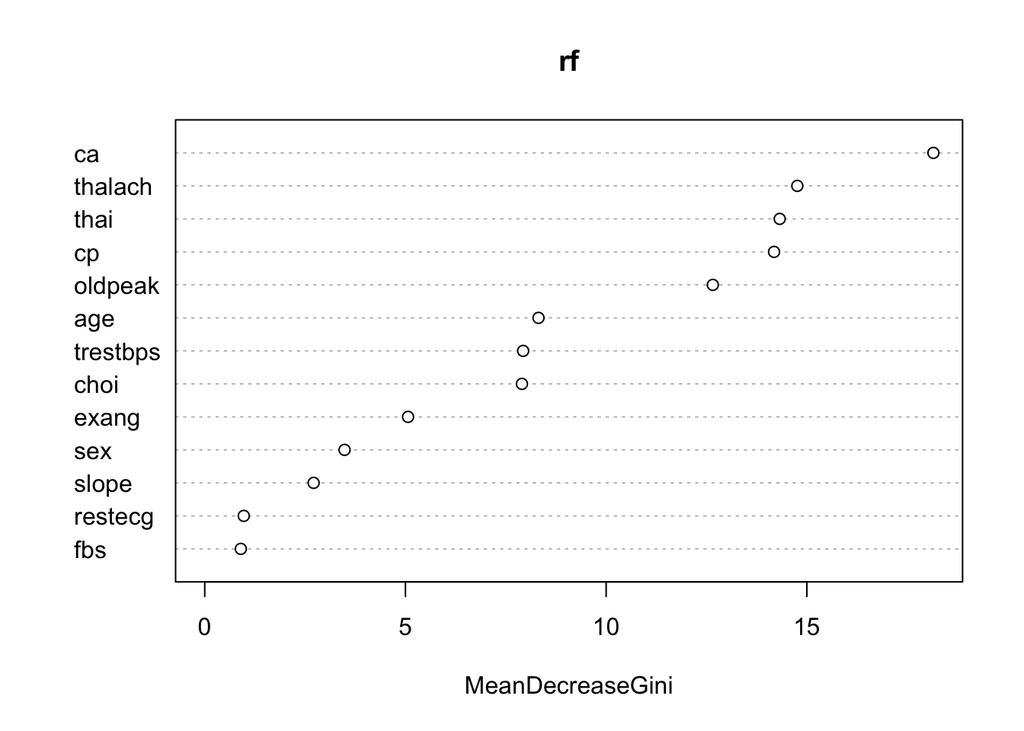

[figure not shown]

```r
library(rpart)
fit=rpart(num ~ .,
          data=train)
plot(fit)
text(fit)
```

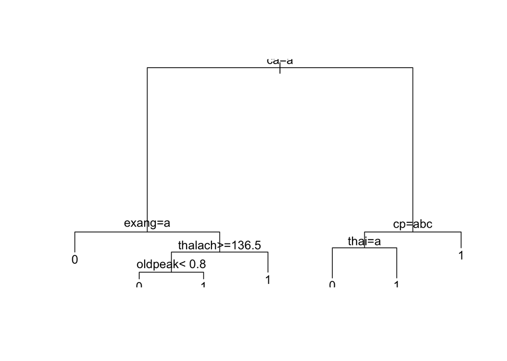

[figure not shown]

[Article Source](https://towardsdatascience.com/random-forest-in-r-f66adf80ec9)